# TBA2101 Final Exam

TBA2102 Student. ANG XUAN ZE

29 April 2021, 1:00 - 3:00 PM

## Instructions

- **Rename your R Markdown file `FA_[MatricNumber].rmd`**, and the output will automatically be `FA_[MatricNumber].html`.
- Select `output: html_document`.
- Include all code chunks, so include `echo=TRUE` in all chunks.
- Replace the placeholder text, “Type your answer here.”, with your own.
- Preinstall and include any `library('package_name')` statements before the exam starts. Remember that there is no Internet connection when the exam is in progress.
- Please copy and paste the question code from Examplify to this Rmarkdown file in the order of exam questions.
- You could code and type your answer in this Rmarkdown file during exam but **keep in mind that you need to copy and paste all your answer (r-chunk and text) into Essay Answer section for each question in Examplify.**
- Submit your both R Markdown file (.rmd) and HTML (.html) to the folder “Exam Submission” in Luminus after Examplify submission and Internet reconnection.
- This Rmarkdown file serves as a reference. **Only answers submitted in Examplify will be graded.** Zero point will be given for blank submission in Examplify even if you have submitted a complete Rmarkdown and HTML files.

## Preparation

```r
# predictive/prescriptive analytics
library(TTR)
library(forecast)
library(olsrr)
library(factoextra)
library(caret)
library(tseries)
library(lpSolve)

# descriptive analytics
library(psych)
library(Rmisc)
library(rcompanion)
library(rpivotTable)
library(EnvStats)
library(car)
library(rstatix)

# general use
library(readxl)
library(dplyr)
library(tidyr)
library(ggplot2) #optional
library(wooldridge)
library(knitr)
```

## Question 1: Engineer Education & Wages

Context: - Dataset: “engin” in wooldridge. The data comes from the Material Requirement Planning Survey carried out in Thailand during 1998. These data are on a sample of 403 engineers in Thailand.

```r
# Run the following to load the data into your work space.
data('engin')
E<-engin
```

The data.frame has 403 observations on 17 variables:

- male: =1 if male
- educ: highest grade completed
- wage: monthly salary, Thai baht
- swage: starting wage
- exper: years on current job
- pexper: previous experience
- lwage: log(wage)
- expersq: exper^2
- highgrad: =1 if high school graduate
- college: =1 if college graduate
- grad: =1 if some graduate school
- polytech: =1 if a polytech
- highdrop: =1 if no high school degree
- lswage: log(swage)
- pexpersq: pexper^2
- mleeduc: male*educ
- mleeduc0: male*(educ - 14)

#### (a) Engineer Education & Wage Profile Dashboard

You are tasked to develop a dashboard to visualize the data. - i. First, there are 5 dummy variables `highgrad`, `college`, `grad`, `polytech`, and `highdrop` that indicate the graduate status of the engineers. Create a new column `graduate`that has the value “High School” if `highgrad`=1; “College” if `college`=1; “Grad School” if `grad`=1; “Poly” if `polytech`=1; and “No High School” if `highdrop`=1. (1 mark) - ii. Create a piechart with the title “Graduate Status (Percentage of Total)” to display the percentage of engineers for each graduate status. Each slice should be labeled with the graduate status, followed by the percentage rounded to the nearest whole number (eg, Poly, XX%). Use different shades of green for each slice of the piechart. (2.5 marks) - iii. Create a barplot to visually compare the mean monthly wage of engineers with different graduate status. Ensure that the barplot has the title “Mean Wages across Graduate Status”, the axes are appropriately labeled and each bar is labeled with the correct Graduate Status. (2.5 marks)

1. New Column `graduate`

```r
E$graduate = NA
E$graduate[E$highgrad == 1] <- "High School"
E$graduate[E$college == 1] <- "College"
E$graduate[E$grad == 1] <- "Grad School"
E$graduate[E$polytech == 1] <- "Poly"
E$graduate[E$highdrop == 1] <- "No High School"
```

2. Pie Chart

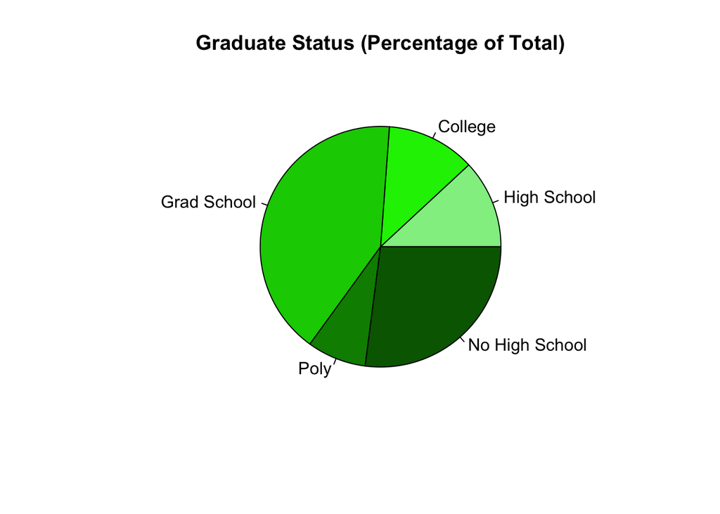

```r
numfreq<-E%>%count(graduate)
pie(numfreq$n, labels = c("High School","College","Grad School","Poly","No High School") ,col = c("lightgreen","green2","green3","green4","darkgreen"),main = "Graduate Status (Percentage of Total)")
```

3. Barplot

[figure not shown]

```r
E$meanwage = NA
E$meanwage <- mean(E$wage)

barplot(E$meanwage,names.arg = E$graduate, xlab = "Graduate status", ylab = "Mean monthly wage",main = "Mean Wages across Graduate Status", col="red", cex.names=0.5)
```

#### (b) Compare Mean Wage across Graduate Status

You are also tasked to use the data to test if any significant differences exist in the mean wage for engineers with different graduate status. Present your hypotheses, the results and conclusions. (4 marks)

## Question 2: Engineer Education & Wages (Regression Analyses)

Context: - Dataset: “engin” in wooldridge. The data comes from the Material Requirement Planning Survey carried out in Thailand during 1998. These data are on a sample of 403 engineers in Thailand.

The data.frame with 403 observations on 17 variables:

- male: =1 if male
- educ: highest grade completed
- wage: monthly salary, Thai baht
- swage: starting wage
- exper: years on current job
- pexper: previous experience
- lwage: log(wage)
- expersq: exper^2
- highgrad: =1 if high school graduate
- college: =1 if college graduate
- grad: =1 if some graduate school
- polytech: =1 if a polytech
- highdrop: =1 if no high school degree
- lswage: log(swage)
- pexpersq: pexper^2
- mleeduc: male*educ
- mleeduc0: male*(educ - 14)

#### (a) Correlation between Education and Experience

Start by computing the Pearson correlations between i) `educ` and `exper` ii) `educ` and `pexper`. (1 mark)

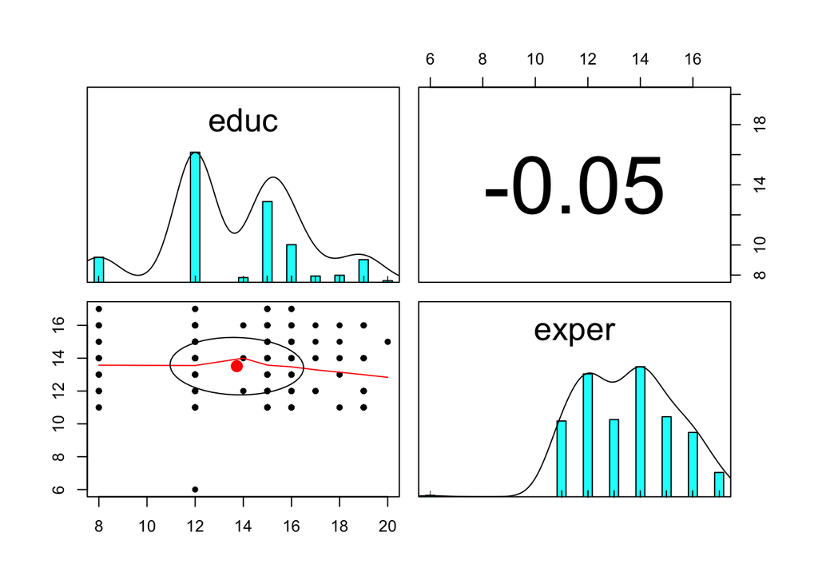

```r
#Pairs panel of `educ` and `exper`
corr1 <- E %>% select(educ,exper)
pairs.panels(corr1)
```

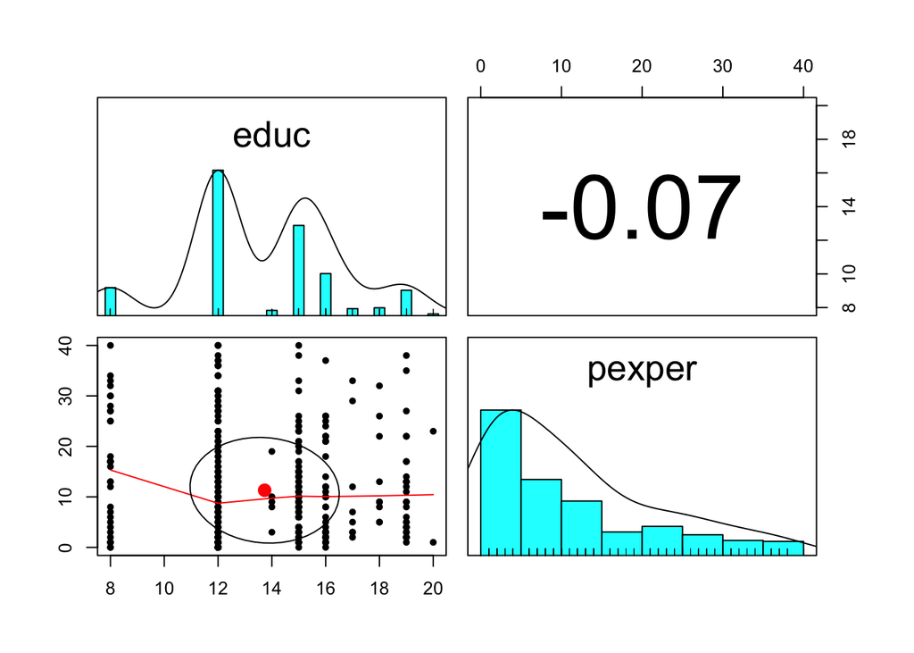

```r
#Pairs panel of `educ` and `pexper`
corr2 <- E %>% select(educ,pexper)
pairs.panels(corr2)
```

```r
#Pearson correlation of `educ` and `exper`
pears1 <- cor(E$educ,E$exper)
print(pears1)
```

```
## [1] -0.05300185
```

```r
#Pearson correlation of `educ` and `pexper`
pears2 <- cor(E$educ,E$pexper)
pears2
```

```
## [1] -0.06884674
```

#### (b) Examine how gender, years of education and experience relates to monthly wage.

- 1. Run a linear regression model of lwage ~ male + educ + exper + pexper. Based on the results, which variables have a significant linear relationship with lwage? Interpret the coefficients of this(ese) significant variable(s). (3 marks)
- 2. Based on your answer in (a), explain if you suspect multicollinearity exists in the model you have just run in b(i)? (1 mark)
- 3. You were told that there is a significant interaction effect between `male` and `educ` on `lwage`. Run the appropriate linear regression model to verify if this statement is true. Interpret the coefficients for the interaction term. Is the model with the interaction term able to predict wage better than the model without the interaction term? (5 marks)

```r
model1<-lm(lwage ~ male + educ + exper + pexper, data = E)
summary(model1)
```

```
##
## Call:
## lm(formula = lwage ~ male + educ + exper + pexper, data = E)
##
## Residuals:
##      Min       1Q   Median       3Q      Max
## -0.53537 -0.17548 -0.01412  0.15464  0.91453
##
## Coefficients:
##              Estimate Std. Error t value Pr(>|t|)
## (Intercept)  8.975743   0.121485  73.883  < 2e-16 ***
## male         0.231425   0.029485   7.849 3.92e-14 ***
## educ         0.086442   0.005279  16.373  < 2e-16 ***
## exper        0.007584   0.007185   1.055    0.292
## pexper      -0.002155   0.001224  -1.761    0.079 .
## ---
## Signif. codes:  0 '***' 0.001 '**' 0.01 '*' 0.05 '.' 0.1 ' ' 1
##
## Residual standard error: 0.2517 on 398 degrees of freedom
## Multiple R-squared:  0.6115, Adjusted R-squared:  0.6076
## F-statistic: 156.6 on 4 and 398 DF,  p-value: < 2.2e-16
```

b(ii)  
(a) Multicollinearity does not exist in the model.

```r
model2<-lm(lwage ~ male + educ, data = E)
summary(model2)
```

```
##
## Call:
## lm(formula = lwage ~ male + educ, data = E)
##
## Residuals:
##     Min      1Q  Median      3Q     Max
## -0.5503 -0.1731 -0.0142  0.1631  0.8835
##
## Coefficients:
##             Estimate Std. Error t value Pr(>|t|)
## (Intercept) 9.042296   0.066724 135.519  < 2e-16 ***
## male        0.220936   0.029022   7.613 1.95e-13 ***
## educ        0.087687   0.005228  16.774  < 2e-16 ***
## ---
## Signif. codes:  0 '***' 0.001 '**' 0.01 '*' 0.05 '.' 0.1 ' ' 1
##
## Residual standard error: 0.2524 on 400 degrees of freedom
## Multiple R-squared:  0.6075, Adjusted R-squared:  0.6056
## F-statistic: 309.6 on 2 and 400 DF,  p-value: < 2.2e-16
```

### Question 3: Linear Optimization for distribution centres

#### Organics Supplier has two distribution centres (Jurong & Tampines) in Singapore that distribute organic milk to 4 retail stores (StoreA, StoreB, StoreC and StoreD). The per-carton delivery costs of transporting the milk from each distribution centre to the retail stores, the amount available in the inventory of each distribution center and the amount ordered at each retail store are shown in the table below. Organics Supplier wants to minimize the cost of transportation while meeting the demands of the retail stores.

| Distribution Centre | StoreA | StoreB | StoreC | StoreD | Supply (No. of Cartons) |
| --- | --- | --- | --- | --- | --- |
| Jurong | $0.60 | $1.70 | $0.60 | $1.05 | 14,000 |
| Tampines | $0.70 | $1.50 | $0.40 | $0.95 | 10,000 |
| Demand (No. of Cartons) | 4,000 | 8,000 | 3,500 | 7,000 |  |

#### (a) Write down your decision variables, the objective function, and ALL constraints that apply for this optimization problem in a table.(3 marks)

Solve this optimization problem in R. What is the minimum cost of delivery given the optimal number of cartons of milk to transport from each distribution centre to the retail stores? Which distribution centre will operate at full capacity in this solution (3 marks)

Let A be the carton of milk send to Store A  
Let B be the carton of milk send to Store B  
Let C be the carton of milk send to Store C  
Let D be the carton of milk send to Store D  
Let J be the carton of milk send from Jurong  
Let T be the carton of milk send from Tampines

[output not shown]

```r
objective.fn <- c(0.6,1.5,0.4,0.95)
const.max <- matrix(c(1, 1, 1, 1),
                    ncol = 1,
                    byrow = TRUE)
const.dir <- c(">=")
const.rhs <- c(24000)

#Solving model
lp.solution <- lp("min", objective.fn, const.max, const.dir, const.rhs, compute.sens = TRUE)
#Decision variables values
lp.solution$solution
```

```
## [1] 0 0 1 0
```

```r
lp.solution
```

```
## Success: the objective function is 0.4
```

#### (b) The Tampines distribution centre has increased its capacity and is now able to supply 11500 cartons of milk. How would this change the total delivery cost? (2 marks)

| Minimize the cost of transportation using decision variables A,B,C,D | Cost = 0.6 x A + 1.50 x B + 0.40 x C + 0.95 x D |
| --- | --- |
| Subject to |  |
| Supply Constraint 1 | A + B + C + D $\leq$ 25500 |
| Non-Negativity Constraint 1 | A +$\quad$+$\quad$+$\quad$ $\geq$ 0 |
| Non-Negativity Constraint 2 | $\quad$+ B +$\quad$+$\quad$ $\geq$ 0 |
| Non-Negativity Constraint 3 | $\quad$+$\quad$+ C +$\quad$ $\geq$ 0 |
| Non-Negativity Constraint 4 | $\quad$+$\quad$+$\quad$+ D $\geq$ 0 |

#### (c) Based on the solution in (a), what would be the additional delivery cost incurred for the Jurong distribution centre to deliver one more carton of milk? (2 marks)